# Information Content in Color Images

Professor Alejando & Ulile

13/01/2021

## Introdução

As imagens coloridas contêm certas propriedades no espaço de cores CEILab. Tais imagens chamadas de “ideal” quando aplicadas técnicas extatisticas pode-se obter uma natureza de informações conhecidas por “maximum realizable color information” (MRCI).

Basicamente MRCI possui os dados distribuidos uniformemente no espaço CIELab. “A”não conformidade" com MRCI é uma medida de distância entre distribuições de imagens observada e a imagem MRCI".

A hipótese principal do presente trabalho consiste em avaliar qualidade da imagem ideal. Graças a diferentes métricas, pode-se medir distância entre distribuições dos dados duma imagem ideal e uma simulada. Uma das métricas mais utilizadas é a divergência de Kullback-Leibler e, consequentemente será utilizada.

Os autores obtêm uma versão empírica da imagem MRCI com os pontos amostrais distribuidos uniformemente no espaço CIELab $[L^*, a^*, b^*]$ limitado no intervalo $[0,100]\times [−200,200]\times [−200,200]$; os pontos válidos são mapeados no espaço $[R, G, B]$ no intervalo $[0, 1]^3$. Somente pontos válidos no espaço RGB são considerados.

## Ensaios

#### Carregamento

```
## From reference white:
## To reference white: D65
## From reference white:
## To reference white: D65
```

Para ver a distribuição dos pontos no espaço “Lab”, pode-se usar a função $plotPixels(...)$ do pacote colordistance.

#### Visualização dos pontos em CIELab

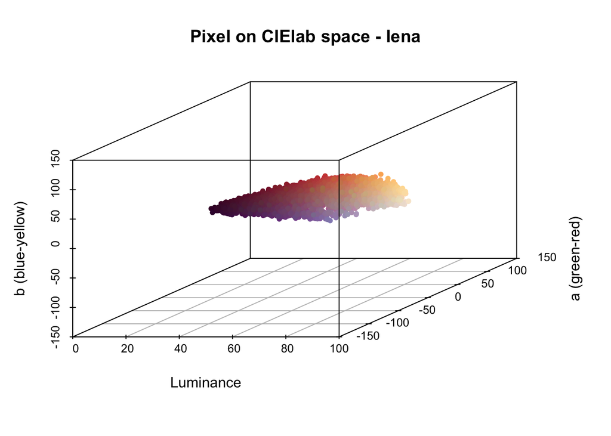

O histograma em baixo nos mostra como os dados do componente L “Luminância” estão agrupados em cada uma das imagens.

**Faça novamente a figura abaixo, mostrando lado a lado a imagem e o histograma da sua componente L**

**Conclua esta seção exploratória mostrando a imagem “ideal” e o histograma da sua banda de luminância**

[figure not shown]

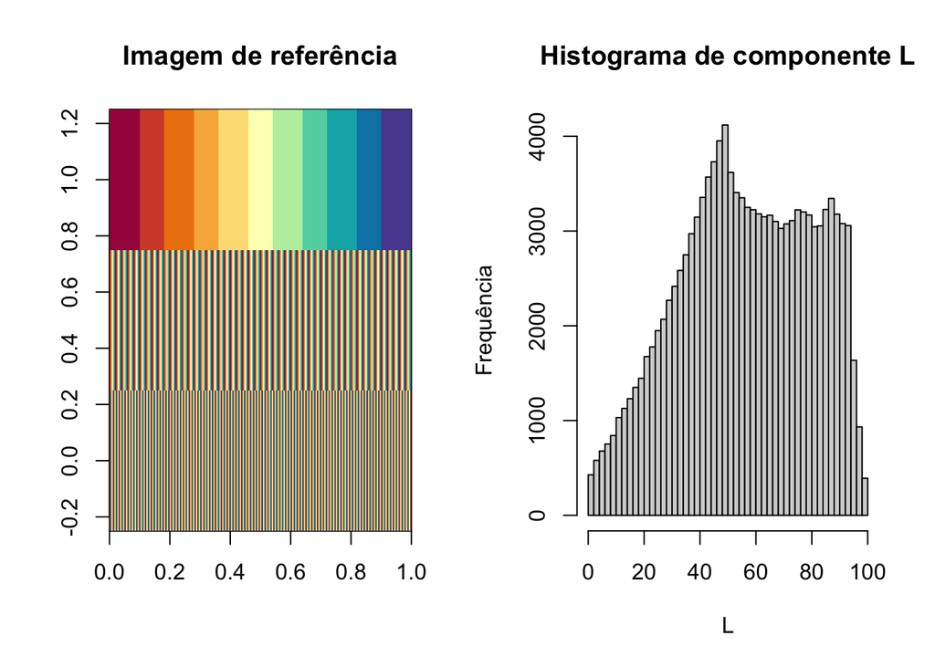

# Aplicação